# mpl_toolkits.mplot3d.axes3d.Axes3D.plot_trisurf

**Axes3D.plot_trisurf(*args, *color=None*, *norm=None*, *vmin=None*, *vmax=None*, *lightsource=None*, *axlim_clip=False*, **kwargs)[[source]](https://github.com/matplotlib/matplotlib/blob/v3.10.8/lib/mpl_toolkits/mplot3d/axes3d.py#L2448-L2548)**

Plot a triangulated surface.

The (optional) triangulation can be specified in one of two ways; either:

```
plot_trisurf(triangulation, ...)
```

where triangulation is a `Triangulation` object, or:

```
plot_trisurf(X, Y, ...)
plot_trisurf(X, Y, triangles, ...)
plot_trisurf(X, Y, triangles=triangles, ...)
```

in which case a Triangulation object will be created. See `Triangulation` for an explanation of these possibilities.

The remaining arguments are:

```
plot_trisurf(..., Z)
```

where *Z* is the array of values to contour, one per point in the triangulation.

**Parameters:**

**X, Y, Z**array-like**

Data values as 1D arrays.

**color**

Color of the surface patches.

**cmap**

A colormap for the surface patches.

**norm**`Normalize`, optional**

An instance of Normalize to map values to colors.

**vmin, vmax**float, optional**

Minimum and maximum value to map.

**shade**bool, default: True**

Whether to shade the facecolors. Shading is always disabled when *cmap* is specified.

**lightsource**`LightSource`, optional**

The lightsource to use when *shade* is True.

**axlim_clip**bool, default: False**

Whether to hide patches with a vertex outside the axes view limits.

Added in version 3.10.

**kwargs**

All other keyword arguments are passed on to `Poly3DCollection`

#### Examples

([`Source code`](https://matplotlib.org/stable/_downloads/352b81410875bbe00f7c64b37a4aa316/trisurf3d.py), [`2x.png`](https://matplotlib.org/stable/_downloads/ff1f27683e3cccad9db9a9087ed47a4e/trisurf3d_00_00.2x.png), [`png`](https://matplotlib.org/stable/_downloads/46a9e89c96d1ce26fd6d1be9dd1ddc64/trisurf3d_00_00.png))

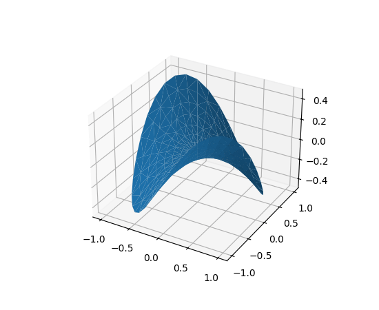

([`Source code`](https://matplotlib.org/stable/_downloads/d335daf8d7e7f5920a65da3298e7b37e/trisurf3d_2.py), [`2x.png`](https://matplotlib.org/stable/_downloads/21bdb838c4900dcc8df24ad82a357edb/trisurf3d_2_00_00.2x.png), [`png`](https://matplotlib.org/stable/_downloads/ae80e0aa505787d6a10572e8570b47de/trisurf3d_2_00_00.png))

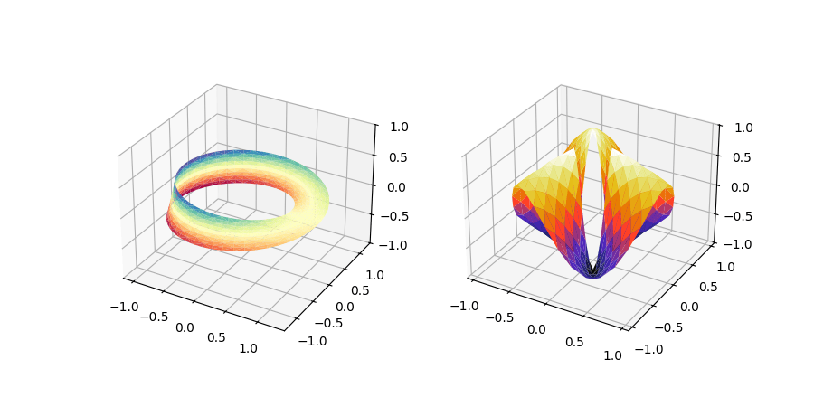

## Examples using `mpl_toolkits.mplot3d.axes3d.Axes3D.plot_trisurf`

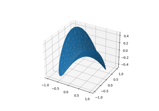

[Triangular 3D surfaces](https://matplotlib.org/stable/gallery/mplot3d/trisurf3d.html)

Triangular 3D surfaces

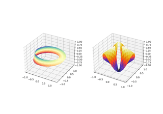

[More triangular 3D surfaces](https://matplotlib.org/stable/gallery/mplot3d/trisurf3d_2.html)

More triangular 3D surfaces

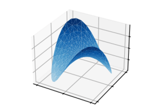

[plot_trisurf(x, y, z)](https://matplotlib.org/stable/plot_types/3D/trisurf3d_simple.html)

plot_trisurf(x, y, z)